### This is the Data Analysis Report of an Automotive Industry dataset

# EDA (`E`xploratory `D`ata `A`nalysis)

- The reasoning behind this approach was to examine the data before building a model
- Today almost every Data scientists and analysts spend most of their time in `Data Wrangling` and `Exploratory Data Analysis also known as EDA`

# What is Exploratory Data Analysis?

Exploratory Data Analysis or EDA technique is used for getting insights from the data. Data Scientists and Analysts try to find `different patterns`, `relations`, and `anomalies in the data` using some statistical graphs and other visualization techniques. Following things are part of EDA :

- Get maximum insights from a data set
- Uncover underlying structure
- Extract important variables from the dataset
- Detect outliers and anomalies(if any)
- Test underlying assumptions
- Determine the optimal factor settings

# Why EDA is important?

- The main purpose of EDA is to
- Detect any errors,
- Outliers as well as
- To understand different patterns in the data.
- It allows Analysts to understand the data better before making any assumptions.
- The outcomes of EDA helps businesses to know their customers, expand their business and take decisions accordingly.

# How to perform EDA?

- Following steps are most commonly used to perform EDA:

## Import libraries and load dataset

```python
import numpy as np
import pandas as pd
import matplotlib.pyplot as plt
import seaborn as sns
```

## Read Data set and see top and bottom rows to have quick glimpse of data

```python
df = pd.read_csv("Automobile_data pycsr.csv")
```

```python
df.head(3)
```

|  | symboling | normalized-losses | make | fuel-type | aspiration | num-of-doors | body-style | drive-wheels | engine-location | wheel-base | ... | engine-size | fuel-system | bore | stroke | compression-ratio | horsepower | peak-rpm | city-mpg | highway-mpg | price |
| --- | --- | --- | --- | --- | --- | --- | --- | --- | --- | --- | --- | --- | --- | --- | --- | --- | --- | --- | --- | --- | --- |
| 0 | 3 | ? | alfa-romero | gas | std | two | convertible | rwd | front | 88.6 | ... | 130 | mpfi | 3.47 | 2.68 | 9.0 | 111 | 5000 | 21 | 27 | 13495 |
| 1 | 3 | ? | alfa-romero | gas | std | two | convertible | rwd | front | 88.6 | ... | 130 | mpfi | 3.47 | 2.68 | 9.0 | 111 | 5000 | 21 | 27 | 16500 |
| 2 | 1 | ? | alfa-romero | gas | std | two | hatchback | rwd | front | 94.5 | ... | 152 | mpfi | 2.68 | 3.47 | 9.0 | 154 | 5000 | 19 | 26 | 16500 |

3 rows × 26 columns

## Get shape of data to understand number of observations

```python
df.shape
```

```
(205, 26)
```

## Get Feature names of dataset

```python
df.keys()
```

```
Index(['symboling', 'normalized-losses', 'make', 'fuel-type', 'aspiration',
       'num-of-doors', 'body-style', 'drive-wheels', 'engine-location',
       'wheel-base', 'length', 'width', 'height', 'curb-weight', 'engine-type',
       'num-of-cylinders', 'engine-size', 'fuel-system', 'bore', 'stroke',
       'compression-ratio', 'horsepower', 'peak-rpm', 'city-mpg',
       'highway-mpg', 'price'],
      dtype='object')
```

```python
df.columns
```

```
Index(['symboling', 'normalized-losses', 'make', 'fuel-type', 'aspiration',
       'num-of-doors', 'body-style', 'drive-wheels', 'engine-location',
       'wheel-base', 'length', 'width', 'height', 'curb-weight', 'engine-type',
       'num-of-cylinders', 'engine-size', 'fuel-system', 'bore', 'stroke',
       'compression-ratio', 'horsepower', 'peak-rpm', 'city-mpg',
       'highway-mpg', 'price'],
      dtype='object')
```

## Get full Decription/summary of dataset

```python
df.describe()
```

|  | symboling | wheel-base | length | width | height | curb-weight | engine-size | compression-ratio | city-mpg | highway-mpg |
| --- | --- | --- | --- | --- | --- | --- | --- | --- | --- | --- |
| count | 205.000000 | 205.000000 | 205.000000 | 205.000000 | 205.000000 | 205.000000 | 205.000000 | 205.000000 | 205.000000 | 205.000000 |
| mean | 0.834146 | 98.756585 | 174.049268 | 65.907805 | 53.724878 | 2555.565854 | 126.907317 | 10.142537 | 25.219512 | 30.751220 |
| std | 1.245307 | 6.021776 | 12.337289 | 2.145204 | 2.443522 | 520.680204 | 41.642693 | 3.972040 | 6.542142 | 6.886443 |
| min | -2.000000 | 86.600000 | 141.100000 | 60.300000 | 47.800000 | 1488.000000 | 61.000000 | 7.000000 | 13.000000 | 16.000000 |
| 25% | 0.000000 | 94.500000 | 166.300000 | 64.100000 | 52.000000 | 2145.000000 | 97.000000 | 8.600000 | 19.000000 | 25.000000 |
| 50% | 1.000000 | 97.000000 | 173.200000 | 65.500000 | 54.100000 | 2414.000000 | 120.000000 | 9.000000 | 24.000000 | 30.000000 |
| 75% | 2.000000 | 102.400000 | 183.100000 | 66.900000 | 55.500000 | 2935.000000 | 141.000000 | 9.400000 | 30.000000 | 34.000000 |
| max | 3.000000 | 120.900000 | 208.100000 | 72.300000 | 59.800000 | 4066.000000 | 326.000000 | 23.000000 | 49.000000 | 54.000000 |

## Get full info about all variables/features of dataset

```python
df.info()
```

```
<class 'pandas.core.frame.DataFrame'>
RangeIndex: 205 entries, 0 to 204
Data columns (total 26 columns):
 #   Column             Non-Null Count  Dtype
---  ------             --------------  -----
 0   symboling          205 non-null    int64
 1   normalized-losses  205 non-null    object
 2   make               205 non-null    object
 3   fuel-type          205 non-null    object
 4   aspiration         205 non-null    object
 5   num-of-doors       205 non-null    object
 6   body-style         205 non-null    object
 7   drive-wheels       205 non-null    object
 8   engine-location    205 non-null    object
 9   wheel-base         205 non-null    float64
```

[output cut: 18 more lines]

## Understand the data types of Dataset and downgrade its type to save memory

```python
for k in df.keys():
    if df[k].dtype != "object":
        print("feature name {}: dtype:{},MIN={},MAX={}".format(k,df[k].dtype,df[k].min(),df[k].max()))
```

```
feature name symboling: dtype:int64,MIN=-2,MAX=3
feature name wheel-base: dtype:float64,MIN=86.6,MAX=120.9
feature name length: dtype:float64,MIN=141.1,MAX=208.1
feature name width: dtype:float64,MIN=60.3,MAX=72.3
feature name height: dtype:float64,MIN=47.8,MAX=59.8
feature name curb-weight: dtype:int64,MIN=1488,MAX=4066
feature name engine-size: dtype:int64,MIN=61,MAX=326
feature name compression-ratio: dtype:float64,MIN=7.0,MAX=23.0
feature name city-mpg: dtype:int64,MIN=13,MAX=49
feature name highway-mpg: dtype:int64,MIN=16,MAX=54
```

### For int64

```python
for k in df.keys():
    if "int" in str(df[k].dtype) and df[k].max() <=255:
        df[k] = df[k].astype("int8")
    if "int" in str(df[k].dtype) and df[k].max() >255:
        df[k] = df[k].astype("int16")
```

### For float64

```python
for k in df.keys():
    if "float" in str(df[k].dtype):
        df[k] = df[k].astype("float16")
```

```python
df.dtypes
```

```
symboling               int8
normalized-losses     object
make                  object
fuel-type             object
aspiration            object
num-of-doors          object
body-style            object
drive-wheels          object
engine-location       object
wheel-base           float16
length               float16
width                float16
height               float16
curb-weight            int16
engine-type           object
num-of-cylinders      object
engine-size            int16
fuel-system           object
bore                  object
stroke                object
compression-ratio    float16
horsepower            object
peak-rpm              object
city-mpg                int8
highway-mpg             int8
price                 object
dtype: object
```

```python
df.info()
```

```
<class 'pandas.core.frame.DataFrame'>
RangeIndex: 205 entries, 0 to 204
Data columns (total 26 columns):
 #   Column             Non-Null Count  Dtype
---  ------             --------------  -----
 0   symboling          205 non-null    int8
 1   normalized-losses  205 non-null    object
 2   make               205 non-null    object
 3   fuel-type          205 non-null    object
 4   aspiration         205 non-null    object
 5   num-of-doors       205 non-null    object
 6   body-style         205 non-null    object
 7   drive-wheels       205 non-null    object
 8   engine-location    205 non-null    object
 9   wheel-base         205 non-null    float16
```

[output cut: 18 more lines]

## See if any missing values are present in data set

```python
df.isnull()
```

|  | symboling | normalized-losses | make | fuel-type | aspiration | num-of-doors | body-style | drive-wheels | engine-location | wheel-base | ... | engine-size | fuel-system | bore | stroke | compression-ratio | horsepower | peak-rpm | city-mpg | highway-mpg | price |
| --- | --- | --- | --- | --- | --- | --- | --- | --- | --- | --- | --- | --- | --- | --- | --- | --- | --- | --- | --- | --- | --- |
| 0 | False | False | False | False | False | False | False | False | False | False | ... | False | False | False | False | False | False | False | False | False | False |
| 1 | False | False | False | False | False | False | False | False | False | False | ... | False | False | False | False | False | False | False | False | False | False |
| 2 | False | False | False | False | False | False | False | False | False | False | ... | False | False | False | False | False | False | False | False | False | False |
| 3 | False | False | False | False | False | False | False | False | False | False | ... | False | False | False | False | False | False | False | False | False | False |
| 4 | False | False | False | False | False | False | False | False | False | False | ... | False | False | False | False | False | False | False | False | False | False |
| ... | ... | ... | ... | ... | ... | ... | ... | ... | ... | ... | ... | ... | ... | ... | ... | ... | ... | ... | ... | ... | ... |
| 200 | False | False | False | False | False | False | False | False | False | False | ... | False | False | False | False | False | False | False | False | False | False |
| 201 | False | False | False | False | False | False | False | False | False | False | ... | False | False | False | False | False | False | False | False | False | False |
| 202 | False | False | False | False | False | False | False | False | False | False | ... | False | False | False | False | False | False | False | False | False | False |
| 203 | False | False | False | False | False | False | False | False | False | False | ... | False | False | False | False | False | False | False | False | False | False |
| 204 | False | False | False | False | False | False | False | False | False | False | ... | False | False | False | False | False | False | False | False | False | False |

205 rows × 26 columns

```python
df.isnull().sum()
```

```
symboling            0
normalized-losses    0
make                 0
fuel-type            0
aspiration           0
num-of-doors         0
body-style           0
drive-wheels         0
engine-location      0
wheel-base           0
length               0
width                0
height               0
curb-weight          0
engine-type          0
num-of-cylinders     0
engine-size          0
fuel-system          0
bore                 0
stroke               0
compression-ratio    0
horsepower           0
peak-rpm             0
city-mpg             0
highway-mpg          0
price                0
dtype: int64
```

## Get unique values for each feature, this will help you to get to know if any unwanted characters are present in dataset

```python
for k in df.keys():
    print(k,df[k].unique()[:10])
```

```
symboling [ 3  1  2  0 -1 -2]
normalized-losses ['?' '164' '158' '192' '188' '121' '98' '81' '118' '148']
make ['alfa-romero' 'audi' 'bmw' 'chevrolet' 'dodge' 'honda' 'isuzu' 'jaguar'
 'mazda' 'mercedes-benz']
fuel-type ['gas' 'diesel']
aspiration ['std' 'turbo']
num-of-doors ['two' 'four' '?']
body-style ['convertible' 'hatchback' 'sedan' 'wagon' 'hardtop']
drive-wheels ['rwd' 'fwd' '4wd']
engine-location ['front' 'rear']
wheel-base [ 88.6  94.5  99.8  99.4 105.8  99.5 101.2 103.5 110.   88.4]
length [168.8 171.2 176.6 177.2 192.8 178.2 176.8 189.  193.8 197. ]
width [64.1 65.5 66.2 66.4 66.3 71.4 67.9 64.8 66.9 70.9]
height [48.8 52.4 54.3 53.1 55.7 55.9 52.  53.7 56.3 53.2]
curb-weight [2548 2823 2337 2824 2507 2844 2954 3086 3053 2395]
engine-type ['dohc' 'ohcv' 'ohc' 'l' 'rotor' 'ohcf' 'dohcv']
num-of-cylinders ['four' 'six' 'five' 'three' 'twelve' 'two' 'eight']
engine-size [130 152 109 136 131 108 164 209  61  90]
fuel-system ['mpfi' '2bbl' 'mfi' '1bbl' 'spfi' '4bbl' 'idi' 'spdi']
bore ['3.47' '2.68' '3.19' '3.13' '3.5' '3.31' '3.62' '2.91' '3.03' '2.97']
stroke ['2.68' '3.47' '3.4' '2.8' '3.19' '3.39' '3.03' '3.11' '3.23' '3.46']
compression-ratio [ 9.   10.    8.    8.5   8.3   7.    8.8   9.5   9.6   9.41]
horsepower ['111' '154' '102' '115' '110' '140' '160' '101' '121' '182']
peak-rpm ['5000' '5500' '5800' '4250' '5400' '5100' '4800' '6000' '4750' '4650']
city-mpg [21 19 24 18 17 16 23 20 15 47]
highway-mpg [27 26 30 22 25 20 29 28 53 43]
price ['13495' '16500' '13950' '17450' '15250' '17710' '18920' '23875' '?'
 '16430']
```

```python
(df == "?").sum()
```

```
symboling             0
normalized-losses    41
make                  0
fuel-type             0
aspiration            0
num-of-doors          2
body-style            0
drive-wheels          0
engine-location       0
wheel-base            0
length                0
width                 0
height                0
curb-weight           0
engine-type           0
num-of-cylinders      0
engine-size           0
fuel-system           0
bore                  4
stroke                4
compression-ratio     0
horsepower            2
peak-rpm              2
city-mpg              0
highway-mpg           0
price                 4
dtype: int64
```

## Visualize missing values of data set

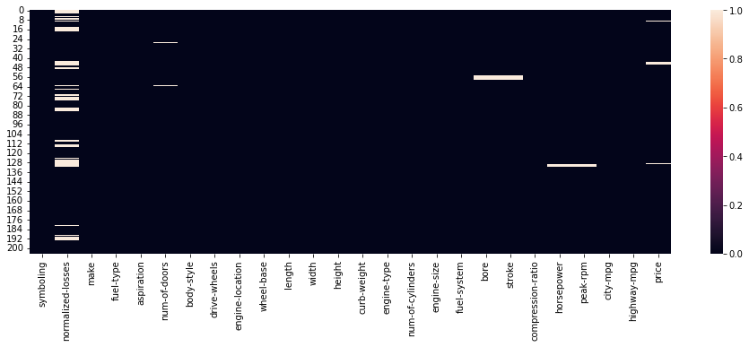

```python
plt.figure(figsize=(16,5))
sns.heatmap(df=="?")
plt.show()
```

## Decide if features needs to be dropped

- Some important factors which helps to drop feature(s):
  - If more than 10% values are empty in a given feature, drop them until it really contributes to EDA
  - Some features like person name, ID, pin code, SSN etc. doesnt add much value because they are unique
  - There could be 2 features which is similar in nature, choose one of them

```python
df.head(2)
```

|  | symboling | normalized-losses | make | fuel-type | aspiration | num-of-doors | body-style | drive-wheels | engine-location | wheel-base | ... | engine-size | fuel-system | bore | stroke | compression-ratio | horsepower | peak-rpm | city-mpg | highway-mpg | price |
| --- | --- | --- | --- | --- | --- | --- | --- | --- | --- | --- | --- | --- | --- | --- | --- | --- | --- | --- | --- | --- | --- |
| 0 | 3 | ? | alfa-romero | gas | std | two | convertible | rwd | front | 88.625 | ... | 130 | mpfi | 3.47 | 2.68 | 9.0 | 111 | 5000 | 21 | 27 | 13495 |
| 1 | 3 | ? | alfa-romero | gas | std | two | convertible | rwd | front | 88.625 | ... | 130 | mpfi | 3.47 | 2.68 | 9.0 | 111 | 5000 | 21 | 27 | 16500 |

2 rows × 26 columns

## Fill missing values

```python
for k in df.keys():
    if "?" in df[k].unique():
        print(k,df[k].dtype)
        df[k] = df[k].replace({"?":np.nan})
```

```
normalized-losses object
num-of-doors object
bore object
stroke object
horsepower object
peak-rpm object
price object
```

```python
df.isnull().sum()
```

```
symboling             0
normalized-losses    41
make                  0
fuel-type             0
aspiration            0
num-of-doors          2
body-style            0
drive-wheels          0
engine-location       0
wheel-base            0
length                0
width                 0
height                0
curb-weight           0
engine-type           0
num-of-cylinders      0
engine-size           0
fuel-system           0
bore                  4
stroke                4
compression-ratio     0
horsepower            2
peak-rpm              2
city-mpg              0
highway-mpg           0
price                 4
dtype: int64
```

```python
df.head(3)
```

|  | symboling | normalized-losses | make | fuel-type | aspiration | num-of-doors | body-style | drive-wheels | engine-location | wheel-base | ... | engine-size | fuel-system | bore | stroke | compression-ratio | horsepower | peak-rpm | city-mpg | highway-mpg | price |
| --- | --- | --- | --- | --- | --- | --- | --- | --- | --- | --- | --- | --- | --- | --- | --- | --- | --- | --- | --- | --- | --- |
| 0 | 3 | NaN | alfa-romero | gas | std | two | convertible | rwd | front | 88.625 | ... | 130 | mpfi | 3.47 | 2.68 | 9.0 | 111 | 5000 | 21 | 27 | 13495 |
| 1 | 3 | NaN | alfa-romero | gas | std | two | convertible | rwd | front | 88.625 | ... | 130 | mpfi | 3.47 | 2.68 | 9.0 | 111 | 5000 | 21 | 27 | 16500 |
| 2 | 1 | NaN | alfa-romero | gas | std | two | hatchback | rwd | front | 94.500 | ... | 152 | mpfi | 2.68 | 3.47 | 9.0 | 154 | 5000 | 19 | 26 | 16500 |

3 rows × 26 columns

```python
df.tail(3)
```

|  | symboling | normalized-losses | make | fuel-type | aspiration | num-of-doors | body-style | drive-wheels | engine-location | wheel-base | ... | engine-size | fuel-system | bore | stroke | compression-ratio | horsepower | peak-rpm | city-mpg | highway-mpg | price |
| --- | --- | --- | --- | --- | --- | --- | --- | --- | --- | --- | --- | --- | --- | --- | --- | --- | --- | --- | --- | --- | --- |
| 202 | -1 | 95 | volvo | gas | std | four | sedan | rwd | front | 109.125 | ... | 173 | mpfi | 3.58 | 2.87 | 8.796875 | 134 | 5500 | 18 | 23 | 21485 |
| 203 | -1 | 95 | volvo | diesel | turbo | four | sedan | rwd | front | 109.125 | ... | 145 | idi | 3.01 | 3.4 | 23.000000 | 106 | 4800 | 26 | 27 | 22470 |
| 204 | -1 | 95 | volvo | gas | turbo | four | sedan | rwd | front | 109.125 | ... | 141 | mpfi | 3.78 | 3.15 | 9.500000 | 114 | 5400 | 19 | 25 | 22625 |

3 rows × 26 columns

```python
df["num-of-doors"].mode()
```

```
0    four
dtype: object
```

```python
df["num-of-doors"] = df["num-of-doors"].fillna(df["num-of-doors"].mode()[0])
```

```python
df["normalized-losses"] = df["normalized-losses"].fillna(df["normalized-losses"].mode()[0])
```

```python
df.isnull().sum()
```

```
symboling            0
normalized-losses    0
make                 0
fuel-type            0
aspiration           0
num-of-doors         0
body-style           0
drive-wheels         0
engine-location      0
wheel-base           0
length               0
width                0
height               0
curb-weight          0
engine-type          0
num-of-cylinders     0
engine-size          0
fuel-system          0
bore                 4
stroke               4
compression-ratio    0
horsepower           2
peak-rpm             2
city-mpg             0
highway-mpg          0
price                4
dtype: int64
```

```python
df["bore"].mode()
```

```
0    3.62
dtype: object
```

```python
df["bore"] = df["bore"].fillna(df["bore"].mode()[0])
```

```python
df["stroke"] = df["stroke"].fillna(df["stroke"].mode()[0])
```

```python
df["horsepower"] = df["horsepower"].fillna(df["horsepower"].mode()[0])
```

```python
df["peak-rpm"] = df["peak-rpm"].fillna(df["peak-rpm"].mode()[0])
```

```python
df["price"] = df["price"].fillna(df["price"].mode()[0])
```

```python
df.isnull().sum()
```

```
symboling            0
normalized-losses    0
make                 0
fuel-type            0
aspiration           0
num-of-doors         0
body-style           0
drive-wheels         0
engine-location      0
wheel-base           0
length               0
width                0
height               0
curb-weight          0
engine-type          0
num-of-cylinders     0
engine-size          0
fuel-system          0
bore                 0
stroke               0
compression-ratio    0
horsepower           0
peak-rpm             0
city-mpg             0
highway-mpg          0
price                0
dtype: int64
```

## Find out features which needs type casting

```python
df["horsepower"] = df["horsepower"].astype("int8")
```

```python
df["horsepower"].dtype
```

```
dtype('int8')
```

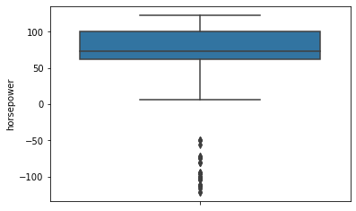

```python
sns.boxplot(y=df["horsepower"])
```

```python
df.head(5)
```

|  | symboling | normalized-losses | make | fuel-type | aspiration | num-of-doors | body-style | drive-wheels | engine-location | wheel-base | ... | engine-size | fuel-system | bore | stroke | compression-ratio | horsepower | peak-rpm | city-mpg | highway-mpg | price |
| --- | --- | --- | --- | --- | --- | --- | --- | --- | --- | --- | --- | --- | --- | --- | --- | --- | --- | --- | --- | --- | --- |
| 0 | 3 | 161 | alfa-romero | gas | std | two | convertible | rwd | front | 88.6250 | ... | 130 | mpfi | 3.47 | 2.68 | 9.0 | 111 | 5000 | 21 | 27 | 13495 |
| 1 | 3 | 161 | alfa-romero | gas | std | two | convertible | rwd | front | 88.6250 | ... | 130 | mpfi | 3.47 | 2.68 | 9.0 | 111 | 5000 | 21 | 27 | 16500 |
| 2 | 1 | 161 | alfa-romero | gas | std | two | hatchback | rwd | front | 94.5000 | ... | 152 | mpfi | 2.68 | 3.47 | 9.0 | -102 | 5000 | 19 | 26 | 16500 |
| 3 | 2 | 164 | audi | gas | std | four | sedan | fwd | front | 99.8125 | ... | 109 | mpfi | 3.19 | 3.4 | 10.0 | 102 | 5500 | 24 | 30 | 13950 |
| 4 | 2 | 164 | audi | gas | std | four | sedan | 4wd | front | 99.3750 | ... | 136 | mpfi | 3.19 | 3.4 | 8.0 | 115 | 5500 | 18 | 22 | 17450 |

5 rows × 26 columns

```python
df["fuel-type"].unique()
```

```
array(['gas', 'diesel'], dtype=object)
```

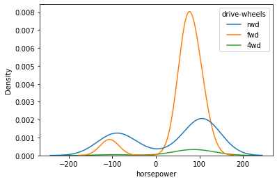

```python
sns.kdeplot(data=df,x="horsepower",hue="drive-wheels")
```

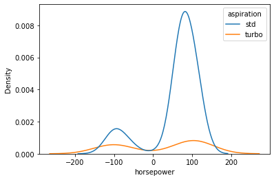

```python
sns.kdeplot(data=df,x="horsepower",hue="aspiration")
```